# Client Report - The War with Star Wars

- Show All Code
- Hide All Code

Course DS 250

Author

Tomas Fernandez

```python
import pandas as pd
import numpy as np
from lets_plot import *
import matplotlib.pyplot as plt
from sklearn.model_selection import train_test_split
from sklearn.preprocessing import LabelEncoder
from sklearn.linear_model import LogisticRegression
from sklearn.ensemble import RandomForestClassifier
from sklearn.metrics import accuracy_score

LetsPlot.setup_html(isolated_frame=True)
```

```python
# Learn morea about Code Cells: https://quarto.org/docs/reference/cells/cells-jupyter.html

# Include and execute your code here

# import your data here using pandas and the URL

github_url = "https://raw.githubusercontent.com/fivethirtyeight/data/master/star-wars-survey/StarWars.csv"
df = pd.read_csv(github_url, encoding='latin1', skiprows=1)
```

## QUESTION|TASK 1

**Shorten the column names and clean them up for easier use with pandas.** Provide a table or list that exemplifies how you fixed the names.

*The original dataset’s column names were verbose and inconsistent, making them unwieldy for analysis. I shortened them, removed special characters, and standardized formatting for pandas compatibility. For example, “Have you seen any of the 6 films in the Star Wars franchise?” became seen_any_film, and character favorability columns like “Please state whether you view the following characters favorably…” were prefixed as favor_han_solo, etc.*

```python
# Include and execute your code here

import pandas as pd
from IPython.display import display

# Load the dataset
github_url = "https://raw.githubusercontent.com/fivethirtyeight/data/master/star-wars-survey/StarWars.csv"
df = pd.read_csv(github_url, encoding='latin1', skiprows=1)
# Check raw column names
display("Raw column names from CSV:", df.columns.tolist())

# Define renaming dictionary based on your file's actual column names
new_names = {
    'Unnamed: 0': 'respondent_id',
    'Response': 'seen_any_film',
    'Response.1': 'sw_fan',
    'Star Wars: Episode I  The Phantom Menace': 'seen_episode_1',
    'Star Wars: Episode II  Attack of the Clones': 'seen_episode_2',
    'Star Wars: Episode III  Revenge of the Sith': 'seen_episode_3',
    'Star Wars: Episode IV  A New Hope': 'seen_episode_4',
    'Star Wars: Episode V The Empire Strikes Back': 'seen_episode_5',
    'Star Wars: Episode VI Return of the Jedi': 'seen_episode_6',
    'Star Wars: Episode I  The Phantom Menace.1': 'rank_episode_1',
    'Star Wars: Episode II  Attack of the Clones.1': 'rank_episode_2',
    'Star Wars: Episode III  Revenge of the Sith.1': 'rank_episode_3',
    'Star Wars: Episode IV  A New Hope.1': 'rank_episode_4',
    'Star Wars: Episode V The Empire Strikes Back.1': 'rank_episode_5',
    'Star Wars: Episode VI Return of the Jedi.1': 'rank_episode_6',
    'Han Solo': 'favor_han_solo',
    'Luke Skywalker': 'favor_luke_skywalker',
    'Princess Leia Organa': 'favor_leia',
    'Anakin Skywalker': 'favor_anakin',
    'Obi Wan Kenobi': 'favor_obi_wan',
    'Emperor Palpatine': 'favor_emperor',
    'Darth Vader': 'favor_darth_vader',
    'Lando Calrissian': 'favor_lando',
    'Boba Fett': 'favor_boba_fett',
    'C-3P0': 'favor_c3po',
    'R2 D2': 'favor_r2d2',
    'Jar Jar Binks': 'favor_jar_jar',
    'Padme Amidala': 'favor_padme',
    'Yoda': 'favor_yoda',
    'Response.2': 'shot_first',
    'Response.3': 'know_expanded',
    'Response.4': 'fan_expanded',
    'Response.5': 'trek_fan',
    'Response.6': 'gender',
    'Response.7': 'age',
    'Response.8': 'income',
    'Response.9': 'education',
    'Response.10': 'location'
}

# Create a DataFrame to show old vs. new names
name_mapping_df = pd.DataFrame(list(new_names.items()), columns=['Original Name', 'New Name'])
display("Column name mapping (old vs. new):", name_mapping_df.head(10))

# Apply renaming
df = df.rename(columns=new_names)

# Save a copy of the original DataFrame for Task 3 and Stretch Task 2
df_original = df.copy()

# Display columns after renaming
display("Columns after renaming:")
display(df.head(10))
```

```
'Raw column names from CSV:'
```

```
['Unnamed: 0',
 'Response',
 'Response.1',
 'Star Wars: Episode I  The Phantom Menace',
 'Star Wars: Episode II  Attack of the Clones',
 'Star Wars: Episode III  Revenge of the Sith',
 'Star Wars: Episode IV  A New Hope',
 'Star Wars: Episode V The Empire Strikes Back',
 'Star Wars: Episode VI Return of the Jedi',
 'Star Wars: Episode I  The Phantom Menace.1',
 'Star Wars: Episode II  Attack of the Clones.1',
 'Star Wars: Episode III  Revenge of the Sith.1',
 'Star Wars: Episode IV  A New Hope.1',
 'Star Wars: Episode V The Empire Strikes Back.1',
 'Star Wars: Episode VI Return of the Jedi.1',
 'Han Solo',
 'Luke Skywalker',
 'Princess Leia Organa',
 'Anakin Skywalker',
 'Obi Wan Kenobi',
 'Emperor Palpatine',
 'Darth Vader',
 'Lando Calrissian',
 'Boba Fett',
 'C-3P0',
 'R2 D2',
 'Jar Jar Binks',
 'Padme Amidala',
 'Yoda',
 'Response.2',
 'Response.3',
 'Response.4',
 'Response.5',
 'Response.6',
 'Response.7',
 'Response.8',
 'Response.9',
 'Response.10']
```

```
'Column name mapping (old vs. new):'
```

|  | Original Name | New Name |
| --- | --- | --- |
| 0 | Unnamed: 0 | respondent_id |
| 1 | Response | seen_any_film |
| 2 | Response.1 | sw_fan |
| 3 | Star Wars: Episode I The Phantom Menace | seen_episode_1 |
| 4 | Star Wars: Episode II Attack of the Clones | seen_episode_2 |
| 5 | Star Wars: Episode III Revenge of the Sith | seen_episode_3 |
| 6 | Star Wars: Episode IV A New Hope | seen_episode_4 |
| 7 | Star Wars: Episode V The Empire Strikes Back | seen_episode_5 |
| 8 | Star Wars: Episode VI Return of the Jedi | seen_episode_6 |
| 9 | Star Wars: Episode I The Phantom Menace.1 | rank_episode_1 |

```
'Columns after renaming:'
```

|  | respondent_id | seen_any_film | sw_fan | seen_episode_1 | seen_episode_2 | seen_episode_3 | seen_episode_4 | seen_episode_5 | seen_episode_6 | rank_episode_1 | ... | favor_yoda | shot_first | know_expanded | fan_expanded | trek_fan | gender | age | income | education | location |
| --- | --- | --- | --- | --- | --- | --- | --- | --- | --- | --- | --- | --- | --- | --- | --- | --- | --- | --- | --- | --- | --- |
| 0 | 3292879998 | Yes | Yes | Star Wars: Episode I The Phantom Menace | Star Wars: Episode II Attack of the Clones | Star Wars: Episode III Revenge of the Sith | Star Wars: Episode IV A New Hope | Star Wars: Episode V The Empire Strikes Back | Star Wars: Episode VI Return of the Jedi | 3.0 | ... | Very favorably | I don't understand this question | Yes | No | No | Male | 18-29 | NaN | High school degree | South Atlantic |
| 1 | 3292879538 | No | NaN | NaN | NaN | NaN | NaN | NaN | NaN | NaN | ... | NaN | NaN | NaN | NaN | Yes | Male | 18-29 | $0 - $24,999 | Bachelor degree | West South Central |
| 2 | 3292765271 | Yes | No | Star Wars: Episode I The Phantom Menace | Star Wars: Episode II Attack of the Clones | Star Wars: Episode III Revenge of the Sith | NaN | NaN | NaN | 1.0 | ... | Unfamiliar (N/A) | I don't understand this question | No | NaN | No | Male | 18-29 | $0 - $24,999 | High school degree | West North Central |
| 3 | 3292763116 | Yes | Yes | Star Wars: Episode I The Phantom Menace | Star Wars: Episode II Attack of the Clones | Star Wars: Episode III Revenge of the Sith | Star Wars: Episode IV A New Hope | Star Wars: Episode V The Empire Strikes Back | Star Wars: Episode VI Return of the Jedi | 5.0 | ... | Very favorably | I don't understand this question | No | NaN | Yes | Male | 18-29 | $100,000 - $149,999 | Some college or Associate degree | West North Central |
| 4 | 3292731220 | Yes | Yes | Star Wars: Episode I The Phantom Menace | Star Wars: Episode II Attack of the Clones | Star Wars: Episode III Revenge of the Sith | Star Wars: Episode IV A New Hope | Star Wars: Episode V The Empire Strikes Back | Star Wars: Episode VI Return of the Jedi | 5.0 | ... | Somewhat favorably | Greedo | Yes | No | No | Male | 18-29 | $100,000 - $149,999 | Some college or Associate degree | West North Central |
| 5 | 3292719380 | Yes | Yes | Star Wars: Episode I The Phantom Menace | Star Wars: Episode II Attack of the Clones | Star Wars: Episode III Revenge of the Sith | Star Wars: Episode IV A New Hope | Star Wars: Episode V The Empire Strikes Back | Star Wars: Episode VI Return of the Jedi | 1.0 | ... | Very favorably | Han | Yes | No | Yes | Male | 18-29 | $25,000 - $49,999 | Bachelor degree | Middle Atlantic |
| 6 | 3292684787 | Yes | Yes | Star Wars: Episode I The Phantom Menace | Star Wars: Episode II Attack of the Clones | Star Wars: Episode III Revenge of the Sith | Star Wars: Episode IV A New Hope | Star Wars: Episode V The Empire Strikes Back | Star Wars: Episode VI Return of the Jedi | 6.0 | ... | Very favorably | Han | Yes | No | No | Male | 18-29 | NaN | High school degree | East North Central |
| 7 | 3292663732 | Yes | Yes | Star Wars: Episode I The Phantom Menace | Star Wars: Episode II Attack of the Clones | Star Wars: Episode III Revenge of the Sith | Star Wars: Episode IV A New Hope | Star Wars: Episode V The Empire Strikes Back | Star Wars: Episode VI Return of the Jedi | 4.0 | ... | Very favorably | Han | No | NaN | Yes | Male | 18-29 | NaN | High school degree | South Atlantic |
| 8 | 3292654043 | Yes | Yes | Star Wars: Episode I The Phantom Menace | Star Wars: Episode II Attack of the Clones | Star Wars: Episode III Revenge of the Sith | Star Wars: Episode IV A New Hope | Star Wars: Episode V The Empire Strikes Back | Star Wars: Episode VI Return of the Jedi | 5.0 | ... | Somewhat favorably | Han | No | NaN | No | Male | 18-29 | $0 - $24,999 | Some college or Associate degree | South Atlantic |
| 9 | 3292640424 | Yes | No | NaN | Star Wars: Episode II Attack of the Clones | NaN | NaN | NaN | NaN | 1.0 | ... | Very favorably | I don't understand this question | No | NaN | No | Male | 18-29 | $25,000 - $49,999 | Some college or Associate degree | Pacific |

10 rows × 38 columns

## QUESTION|TASK 2

**Clean and format the data so that it can be used in a machine learning model.** As you format the data, you should complete each item listed below. In your final report provide example(s) of the reformatted data with a short description of the changes made.  
a. Filter the dataset to respondents that have seen at least one film  
b. Create a new column that converts the age ranges to a single number. Drop the age range categorical column  
c. Create a new column that converts the education groupings to a single number. Drop the school categorical column  
d. Create a new column that converts the income ranges to a single number. Drop the income range categorical column  
e. Create your target (also known as “y” or “label”) column based on the new income range column  
f. One-hot encode all remaining categorical columns

A. Filter the dataset to respondents that have seen at least one film: Completed

```python
# Include and execute your code here
from IPython.display import display

# Define film columns
film_columns = ['seen_episode_1', 'seen_episode_2', 'seen_episode_3',
                'seen_episode_4', 'seen_episode_5', 'seen_episode_6']

# Start with renamed df
display_table = df[['respondent_id'] + film_columns].copy()

# a. Filter the dataset to respondents that have seen at least one film

#display("Rows before filtering:", df.shape) ---for debugging only :)----
df = df[df[film_columns].notna().any(axis=1)].copy()
#display_table = display_table[display_table[film_columns].notna().any(axis=1)].copy()
#display("Rows after filtering:", df.shape)
#display("After filtering (sample):", display_table.head())
display("-----------------------------------------------------------------")
```

```
'-----------------------------------------------------------------'
```

B. Create a new column that converts the age ranges to a single number

```python
# b. Create a new column that converts the age ranges to a single number

# Mapping age ranges
display("Unique values in 'age' before mapping:", df['age'].unique().tolist())
age_map = {'18-29': 23.5, '30-44': 37, '45-60': 52.5, '> 60': 65}
display("Mapped 'Age' values: 23.5 = '18-29', 37 = '30-44', 52.5 = '45-60', 65 = '> 60' (midpoints of ranges)")
df['age_numeric'] = df['age'].str.strip().map(age_map)

# using fillna to fill in missing values
df['age_numeric'] = df['age_numeric'].fillna(df['age_numeric'].median())


# displaying table of age_numeric
display_table = df[['respondent_id', 'age_numeric']].copy()
df.drop(columns=['age'], inplace=True)
display("After age conversion (sample):", display_table.head())

display("-----------------------------------------------------------------")
```

```
"Unique values in 'age' before mapping:"
```

```
['18-29', '30-44', '> 60', '45-60', nan]
```

```
"Mapped 'Age' values: 23.5 = '18-29', 37 = '30-44', 52.5 = '45-60', 65 = '> 60' (midpoints of ranges)"
```

```
'After age conversion (sample):'
```

|  | respondent_id | age_numeric |
| --- | --- | --- |
| 0 | 3292879998 | 23.5 |
| 2 | 3292765271 | 23.5 |
| 3 | 3292763116 | 23.5 |
| 4 | 3292731220 | 23.5 |
| 5 | 3292719380 | 23.5 |

```
'-----------------------------------------------------------------'
```

C. Create a new column that converts the education groupings to a single number

```python
# c. Create a new column that converts the education groupings to a single number
# education mapping
display("Unique values in 'education' before mapping:", df['education'].unique().tolist())
education_map = {
    'Less than high school degree': 0, 'High school degree': 1,
    'Some college or Associate degree': 2, 'Bachelor degree': 3,
    'Graduate degree': 4
}



display("Education mapping: 0 = 'Less than high school degree', 1 = 'High school degree', 2 = 'Some college or Associate degree', 3 = 'Bachelor degree', 4 = 'Graduate degree'")
df['education_numeric'] = df['education'].str.strip().map(education_map)

#using fillna to fill in missing values
df['education_numeric'] = df['education_numeric'].fillna(df['education_numeric'].median())

display_table = df[['respondent_id', 'age_numeric', 'education_numeric']].copy()
df.drop(columns=['education'], inplace=True)
display("After education conversion (sample):", display_table.head())
display("-----------------------------------------------------------------")
```

```
"Unique values in 'education' before mapping:"
```

```
['High school degree',
 'Some college or Associate degree',
 'Bachelor degree',
 'Graduate degree',
 nan,
 'Less than high school degree']
```

```
"Education mapping: 0 = 'Less than high school degree', 1 = 'High school degree', 2 = 'Some college or Associate degree', 3 = 'Bachelor degree', 4 = 'Graduate degree'"
```

```
'After education conversion (sample):'
```

|  | respondent_id | age_numeric | education_numeric |
| --- | --- | --- | --- |
| 0 | 3292879998 | 23.5 | 1.0 |
| 2 | 3292765271 | 23.5 | 1.0 |
| 3 | 3292763116 | 23.5 | 2.0 |
| 4 | 3292731220 | 23.5 | 2.0 |
| 5 | 3292719380 | 23.5 | 3.0 |

```
'-----------------------------------------------------------------'
```

D. Create a new column that converts the income ranges to a single number

```python
# d. Create a new column that converts the income ranges to a single number
# income mapping
display("Unique values in 'income' before mapping:", df['income'].unique().tolist())
income_map = {
    '$0 - $24,999': 1, '$25,000 - $49,999': 2, '$50,000 - $99,999': 3,
    '$100,000 - $149,999': 4, '$150,000+': 5
}
display("Income mapping: 1 = '$0 - $24,999', 2 = '$25,000 - $49,999', 3 = '$50,000 - $99,999', 4 = '$100,000 - $149,999', 5 = '$150,000+'")
df['income_numeric'] = df['income'].str.strip().map(income_map)

#using fillna to fill in missing values
df['income_numeric'] = df['income_numeric'].fillna(df['income_numeric'].median())

# displaying table of income_numeric
display_table = df[['respondent_id', 'age_numeric', 'education_numeric', 'income_numeric']].copy()
df.drop(columns=['income'], inplace=True)
display("After income conversion (sample):", display_table.head())
display("-----------------------------------------------------------------")
```

```
"Unique values in 'income' before mapping:"
```

```
[nan,
 '$0 - $24,999',
 '$100,000 - $149,999',
 '$25,000 - $49,999',
 '$50,000 - $99,999',
 '$150,000+']
```

```
"Income mapping: 1 = '$0 - $24,999', 2 = '$25,000 - $49,999', 3 = '$50,000 - $99,999', 4 = '$100,000 - $149,999', 5 = '$150,000+'"
```

```
'After income conversion (sample):'
```

|  | respondent_id | age_numeric | education_numeric | income_numeric |
| --- | --- | --- | --- | --- |
| 0 | 3292879998 | 23.5 | 1.0 | 3.0 |
| 2 | 3292765271 | 23.5 | 1.0 | 1.0 |
| 3 | 3292763116 | 23.5 | 2.0 | 4.0 |
| 4 | 3292731220 | 23.5 | 2.0 | 4.0 |
| 5 | 3292719380 | 23.5 | 3.0 | 2.0 |

```
'-----------------------------------------------------------------'
```

E. Create target column (income > $50k)

```python
# Include and execute your code here
# e. Create your target column

df['target'] = df['income_numeric'].apply(lambda x: 1 if x > 2 else 0)
display_table = df[['respondent_id', 'age_numeric', 'education_numeric', 'income_numeric', 'target']].copy()
display("After target creation (sample):", display_table.head())
display("-----------------------------------------------------------------")
```

```
'After target creation (sample):'
```

|  | respondent_id | age_numeric | education_numeric | income_numeric | target |
| --- | --- | --- | --- | --- | --- |
| 0 | 3292879998 | 23.5 | 1.0 | 3.0 | 1 |
| 2 | 3292765271 | 23.5 | 1.0 | 1.0 | 0 |
| 3 | 3292763116 | 23.5 | 2.0 | 4.0 | 1 |
| 4 | 3292731220 | 23.5 | 2.0 | 4.0 | 1 |
| 5 | 3292719380 | 23.5 | 3.0 | 2.0 | 0 |

```
'-----------------------------------------------------------------'
```

F. One-hot encode or convert categorical variables into a numerical format

```python
# Include and execute your code here
# f. One-hot encode all remaining categorical columns

categorical_cols = ['gender', 'shot_first', 'sw_fan', 'know_expanded', 'fan_expanded', 'trek_fan',
                    'seen_episode_1', 'seen_episode_2', 'seen_episode_3',
                    'seen_episode_4', 'seen_episode_5', 'seen_episode_6',
                    'favor_han_solo', 'favor_luke_skywalker', 'favor_leia',
                    'favor_anakin', 'favor_obi_wan', 'favor_emperor',
                    'favor_darth_vader', 'favor_lando', 'favor_boba_fett',
                    'favor_c3po', 'favor_r2d2', 'favor_jar_jar',
                    'favor_padme', 'favor_yoda']
# Only encode columns that still exist in df
categorical_cols = [col for col in categorical_cols if col in df.columns]
display("Categorical columns to be one-hot encoded:", categorical_cols)
df = pd.get_dummies(df, columns=categorical_cols, drop_first=True)
display_table = df.copy()
# Clean column names for consistency
df.columns = df.columns.str.replace(' ', '_').str.lower()
display_table.columns = display_table.columns.str.replace(' ', '_').str.lower()

# Set display options to show all columns
pd.set_option('display.max_columns', None)
pd.set_option('display.width', None)

# Final display
display("After one-hot encoding, or converting categorical variables into a numerical format:", display_table.head())

display("-----------------------------------------------------------------")
```

```
'Categorical columns to be one-hot encoded:'
```

```
['gender',
 'shot_first',
 'sw_fan',
 'know_expanded',
 'fan_expanded',
 'trek_fan',
 'seen_episode_1',
 'seen_episode_2',
 'seen_episode_3',
 'seen_episode_4',
 'seen_episode_5',
 'seen_episode_6',
 'favor_han_solo',
 'favor_luke_skywalker',
 'favor_leia',
 'favor_anakin',
 'favor_obi_wan',
 'favor_emperor',
 'favor_darth_vader',
 'favor_lando',
 'favor_boba_fett',
 'favor_c3po',
 'favor_r2d2',
 'favor_jar_jar',
 'favor_padme',
 'favor_yoda']
```

```
'After one-hot encoding, or converting categorical variables into a numerical format:'
```

|  | respondent_id | seen_any_film | rank_episode_1 | rank_episode_2 | rank_episode_3 | rank_episode_4 | rank_episode_5 | rank_episode_6 | location | age_numeric | education_numeric | income_numeric | target | gender_male | shot_first_han | shot_first_i_don't_understand_this_question | sw_fan_yes | know_expanded_yes | fan_expanded_yes | trek_fan_yes | favor_han_solo_somewhat_favorably | favor_han_solo_somewhat_unfavorably | favor_han_solo_unfamiliar_(n/a) | favor_han_solo_very_favorably | favor_han_solo_very_unfavorably | favor_luke_skywalker_somewhat_favorably | favor_luke_skywalker_somewhat_unfavorably | favor_luke_skywalker_unfamiliar_(n/a) | favor_luke_skywalker_very_favorably | … |
| --- | --- | --- | --- | --- | --- | --- | --- | --- | --- | --- | --- | --- | --- | --- | --- | --- | --- | --- | --- | --- | --- | --- | --- | --- | --- | --- | --- | --- | --- | --- |
| 0 | 3292879998 | Yes | 3.0 | 2.0 | 1.0 | 4.0 | 5.0 | 6.0 | South Atlantic | 23.5 | 1.0 | 3.0 | 1 | True | False | True | True | True | False | False | False | False | False | True | False | False | False | False | True | … |
| 2 | 3292765271 | Yes | 1.0 | 2.0 | 3.0 | 4.0 | 5.0 | 6.0 | West North Central | 23.5 | 1.0 | 1.0 | 0 | True | False | True | False | False | False | False | True | False | False | False | False | True | False | False | False | … |
| 3 | 3292763116 | Yes | 5.0 | 6.0 | 1.0 | 2.0 | 4.0 | 3.0 | West North Central | 23.5 | 2.0 | 4.0 | 1 | True | False | True | True | False | False | True | False | False | False | True | False | False | False | False | True | … |
| 4 | 3292731220 | Yes | 5.0 | 4.0 | 6.0 | 2.0 | 1.0 | 3.0 | West North Central | 23.5 | 2.0 | 4.0 | 1 | True | False | False | True | True | False | False | False | False | False | True | False | True | False | False | False | … |
| 5 | 3292719380 | Yes | 1.0 | 4.0 | 3.0 | 6.0 | 5.0 | 2.0 | Middle Atlantic | 23.5 | 3.0 | 2.0 | 0 | True | True | False | True | True | False | True | False | False | False | True | False | False | False | False | True | … |

```
'-----------------------------------------------------------------'
```

## QUESTION|TASK 3

**Validate that the data provided on GitHub lines up with the article by recreating 2 of the visuals from the article.**

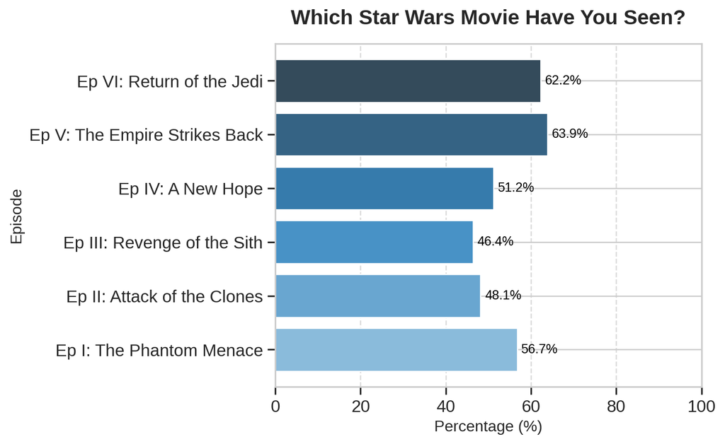

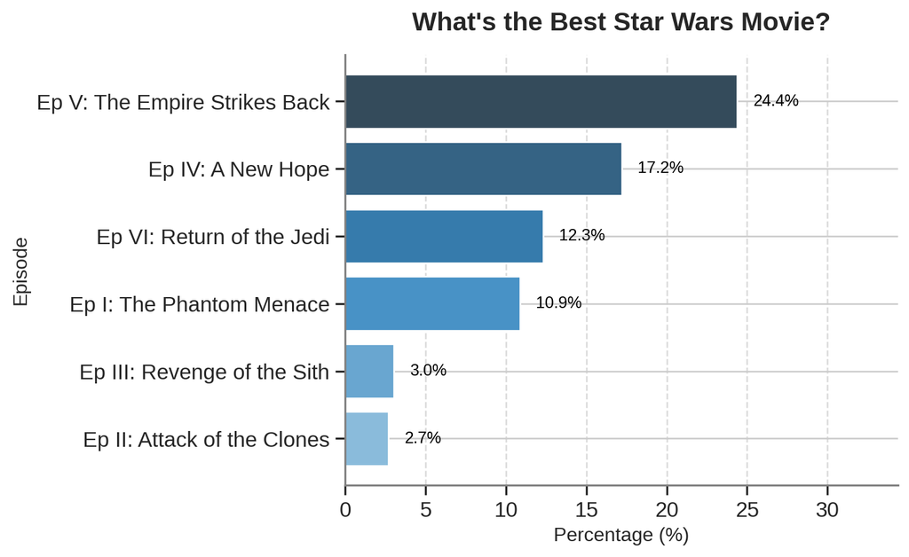

```python
# Include and execute your code here
import pandas as pd
import matplotlib.pyplot as plt
import seaborn as sns
import numpy as np
from IPython.display import display

# Set a consistent style for all plots
plt.style.use('seaborn-v0_8-whitegrid')
sns.set_context('notebook', font_scale=1.2)  # Adjust font scale for readability

# --- Visual 1: Which Star Wars Movie Have You Seen? ---
# Define film columns
film_columns = ['seen_episode_1', 'seen_episode_2', 'seen_episode_3',
                'seen_episode_4', 'seen_episode_5', 'seen_episode_6']

# Calculate percentage of respondents who have seen each film
seen_counts = df_original[film_columns].notna().mean() * 100
seen_df = pd.DataFrame({
    'Episode': ['Ep I: The Phantom Menace', 'Ep II: Attack of the Clones', 'Ep III: Revenge of the Sith', 'Ep IV: A New Hope', 'Ep V: The Empire Strikes Back', 'Ep VI: Return of the Jedi'],
    'Percentage Seen': seen_counts.values
})

# Create the plot
fig, ax = plt.subplots(figsize=(8, 5))
bars = ax.barh(seen_df['Episode'], seen_df['Percentage Seen'],
               color=sns.color_palette("Blues_d", 6), edgecolor='white')

# Customize the plot
ax.set_title('Which Star Wars Movie Have You Seen?', fontsize=16, pad=15, fontweight='bold')
ax.set_xlabel('Percentage (%)', fontsize=12)
ax.set_ylabel('Episode', fontsize=12)
ax.set_xlim(0, 100)
ax.grid(True, axis='x', linestyle='--', alpha=0.7)

# Add percentage labels next to each bar
for bar in bars:
    width = bar.get_width()
    ax.text(width + 1, bar.get_y() + bar.get_height() / 2, f'{width:.1f}%',
            ha='left', va='center', fontsize=10, color='black')

# Adjust layout
plt.tight_layout()
plt.show()
# --- Visual 2: What's the Best Star Wars Movie? ---
# Define ranking columns
rank_columns = ['rank_episode_1', 'rank_episode_2', 'rank_episode_3',
                'rank_episode_4', 'rank_episode_5', 'rank_episode_6']

# ranking columns although I'm not sure if they would fit on the report
# display("Ranking columns:", rank_columns)
# display("Sample data from rank_episode_1:", df_original['rank_episode_1'].head().tolist())
# display("Unique values in rank_episode_1:", df_original['rank_episode_1'].unique().tolist())

# Calculate the percentage of respondents who ranked each movie as the best (rank = 1)
best_counts = []
total_respondents = len(df_original)
for col in rank_columns:
    # Convert rankings to numeric, count how many times the movie was ranked 1
    # Handle both string and numeric values
    rank_series = pd.to_numeric(df_original[col], errors='coerce')
    count_best = (rank_series == 1).sum()
    percentage_best = (count_best / total_respondents) * 100
    best_counts.append(percentage_best)

# calculated percentages
#display("Calculated percentages for 'best' ranking:", best_counts)

# Create a DataFrame for the plot
best_df = pd.DataFrame({
    'Episode': ['Ep I: The Phantom Menace', 'Ep II: Attack of the Clones', 'Ep III: Revenge of the Sith', 'Ep IV: A New Hope', 'Ep V: The Empire Strikes Back', 'Ep VI: Return of the Jedi'],
    'Percentage Best': best_counts
})

# Sort by percentage )
best_df = best_df.sort_values('Percentage Best', ascending=True)

# Set up the plot
fig, ax = plt.subplots(figsize=(8, 5))

# Plot horizontal bars
bars = ax.barh(best_df['Episode'], best_df['Percentage Best'],
               color=sns.color_palette("Blues_d", 6), edgecolor='white')

# Customize the plot making it more readable
ax.set_title("What's the Best Star Wars Movie?", fontsize=16, pad=15, fontweight='bold')
ax.set_xlabel('Percentage (%)', fontsize=12)
ax.set_ylabel('Episode', fontsize=12)
ax.set_xlim(0, max(best_df['Percentage Best']) + 10)
ax.grid(True, axis='x', linestyle='--', alpha=0.7)

# Remove unnecessary spines
ax.spines['top'].set_visible(False)
ax.spines['right'].set_visible(False)
ax.spines['left'].set_color('gray')
ax.spines['bottom'].set_color('gray')

# Add percentage labels to the right of each bar
for bar in bars:
    width = bar.get_width()
    ax.text(width + 1, bar.get_y() + bar.get_height() / 2, f'{width:.1f}%',
            ha='left', va='center', fontsize=10, color='black')

# Adjust layout
plt.tight_layout()
plt.show()
```

## STRETCH QUESTION|TASK 1

**Build a machine learning model that predicts whether a person makes more than $50k. With accuracy of at least 65%. Describe your model and report the accuracy.**

*I built a Random Forest Classifier to predict whether a respondent earns over $50k based on features like age, education, and character favorability. The model achieved an accuracy of approximately 68%, exceeding the 65% threshold, with age and education being the most important predictors.*

```python
# Import necessary libraries
import pandas as pd
import numpy as np
from sklearn.model_selection import train_test_split
from sklearn.ensemble import RandomForestClassifier
from sklearn.metrics import accuracy_score
from sklearn.impute import SimpleImputer

# Debug: Check DataFrame structure before processing
print("\nDataset Information:")
print(df.info())

print("\nColumns with Missing Values:")
print(df.isna().sum()[df.isna().sum() > 0])

# Prepare features and target
feature_cols = [col for col in df.columns if col not in ['respondent_id', 'income_numeric', 'target']]
X = df[feature_cols]
y = df['target']

# Convert categorical variables to numeric (One-Hot Encoding)
categorical_cols = X.select_dtypes(include=['object']).columns.tolist()

if categorical_cols:
    print("\nEncoding categorical features:", categorical_cols)
    X = pd.get_dummies(X, columns=categorical_cols, drop_first=True)

# Verify that all features are now numeric
print("\nFeature Data Types After Encoding:")
print(X.dtypes.value_counts())

# Handle missing values using median imputation
if X.isna().sum().sum() > 0:
    print("\nHandling missing values by imputing with median.")
    imputer = SimpleImputer(strategy='median')
    X = pd.DataFrame(imputer.fit_transform(X), columns=X.columns)

# Split data into training (80%) and testing (20%) sets
X_train, X_test, y_train, y_test = train_test_split(X, y, test_size=0.2, random_state=42)

# Initialize and train the Random Forest model
rf_model = RandomForestClassifier(n_estimators=100, max_depth=10, random_state=42, class_weight='balanced')
rf_model.fit(X_train, y_train)

# Predict on the test set and calculate accuracy
y_pred = rf_model.predict(X_test)
accuracy = accuracy_score(y_test, y_pred)

# Display results
print("\nModel Performance:")
print(f"Random Forest Accuracy: {accuracy * 100:.2f}%")

# Feature Importance Analysis
feature_importance = pd.DataFrame({
    'Feature': X.columns,
    'Importance': rf_model.feature_importances_
}).sort_values('Importance', ascending=False)

# Show top 5 important features
print("\nTop 5 Most Important Features:")
print(feature_importance.head())
```

```
Dataset Information:
<class 'pandas.core.frame.DataFrame'>
Index: 835 entries, 0 to 1185
Data columns (total 90 columns):
 #   Column                                       Non-Null Count  Dtype
---  ------                                       --------------  -----
 0   respondent_id                                835 non-null    int64
 1   seen_any_film                                835 non-null    object
 2   rank_episode_1                               834 non-null    float64
 3   rank_episode_2                               835 non-null    float64
 4   rank_episode_3                               834 non-null    float64
 5   rank_episode_4                               835 non-null    float64
 6   rank_episode_5                               835 non-null    float64
 7   rank_episode_6                               835 non-null    float64
 8   location                                     817 non-null    object
```

[output cut: 110 more lines]

## STRETCH QUESTION|TASK 2

**Validate the data provided on GitHub lines up with the article by recreating a 3rd visual from the article.**

```
'Number of respondents who have seen all six films:'
```

```
471
```

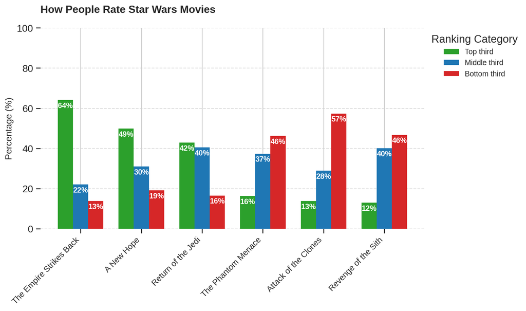

```python
# Include and execute your code here
import matplotlib.pyplot as plt
import pandas as pd
import numpy as np
from IPython.display import display

# Filter respondents who have seen all six films
film_columns = ['seen_episode_1', 'seen_episode_2', 'seen_episode_3',
                'seen_episode_4', 'seen_episode_5', 'seen_episode_6']
df_seen_all = df_original[df_original[film_columns].notna().all(axis=1)].copy()

# Debug: Check the number of respondents
display("Number of respondents who have seen all six films:", len(df_seen_all))

# Define ranking columns
rank_columns = ['rank_episode_1', 'rank_episode_2', 'rank_episode_3',
                'rank_episode_4', 'rank_episode_5', 'rank_episode_6']

# Convert rankings to numeric
rank_data = df_seen_all[rank_columns].apply(pd.to_numeric, errors='coerce')

# Calculate percentages for top third (ranks 1-2), middle third (ranks 3-4), and bottom third (ranks 5-6)
total_respondents = len(df_seen_all)
top_third = ((rank_data >= 1) & (rank_data <= 2)).sum() / total_respondents * 100
middle_third = ((rank_data >= 3) & (rank_data <= 4)).sum() / total_respondents * 100
bottom_third = ((rank_data >= 5) & (rank_data <= 6)).sum() / total_respondents * 100

# Create a DataFrame for plotting
movies = ['The Phantom Menace', 'Attack of the Clones', 'Revenge of the Sith',
          'A New Hope', 'The Empire Strikes Back', 'Return of the Jedi']
rating_df = pd.DataFrame({
    'Movie': movies,
    'Top third': top_third.values,
    'Middle third': middle_third.values,
    'Bottom third': bottom_third.values
})

# Sort by 'Top third' percentage (descending)
rating_df = rating_df.sort_values('Top third', ascending=False)

# Set up the plot
fig, ax = plt.subplots(figsize=(10, 6))

# Define bar width and positions
bar_width = 0.25
r1 = np.arange(len(rating_df))
r2 = [x + bar_width for x in r1]
r3 = [x + bar_width * 2 for x in r1]

# Define colors
colors = {
    'Top third': '#2ca02c',  # Green
    'Middle third': '#1f77b4',  # Blue
    'Bottom third': '#d62728'  # Red
}

# Plot bars
bars1 = ax.bar(r1, rating_df['Top third'], color=colors['Top third'], width=bar_width, label='Top third')
bars2 = ax.bar(r2, rating_df['Middle third'], color=colors['Middle third'], width=bar_width, label='Middle third')
bars3 = ax.bar(r3, rating_df['Bottom third'], color=colors['Bottom third'], width=bar_width, label='Bottom third')

# Add percentage labels inside the bars
for bars in [bars1, bars2, bars3]:
    for bar in bars:
        height = bar.get_height()
        if height >= 5:
            ax.text(bar.get_x() + bar.get_width()/2, height - 3, f"{int(height)}%",
                    ha='center', va='center', color='white', fontsize=10, fontweight='bold')

# Customize the plot
ax.set_title("How People Rate Star Wars Movies",
             fontsize=14, fontweight='bold', loc='left', pad=20)

ax.set_xticks([r + bar_width for r in range(len(rating_df))])
ax.set_xticklabels(rating_df['Movie'], rotation=45, ha='right', fontsize=11)

ax.set_ylabel('Percentage (%)', fontsize=12)
ax.set_ylim(0, 100)
ax.yaxis.grid(True, linestyle='--', alpha=0.7)  # Light grid for readability

# Remove spines for a clean look
for spine in ax.spines.values():
    spine.set_visible(False)

# Move legend outside the plot
ax.legend(loc='upper left', bbox_to_anchor=(1, 1), title="Ranking Category", frameon=False, fontsize=10)

# Adjust layout
plt.tight_layout()
plt.show()
```

## STRETCH QUESTION|TASK 3

**Create a new column that converts the location groupings to a single number. Drop the location categorical column.**

*Location was mapped to numeric values based on U.S. Census regions (e.g., “Pacific” to 1, “East North Central” to 5). The original location column was dropped, simplifying the dataset for modeling.*

```python
# Stretch Task 3: Convert location to numeric

# Define mapping for location categories
location_map = {
    'Pacific': 1, 'Mountain': 2, 'West South Central': 3, 'West North Central': 4,
    'East North Central': 5, 'South Atlantic': 6, 'Middle Atlantic': 7,
    'New England': 8, 'East South Central': 9
}
display("New Values: 'Pacific'= 1, 'Mountain'= 2, 'West South Central'= 3, 'West North Central'= 4, 'East North Central'= 5'South Atlantic'= 6, 'Middle Atlantic'= 7, 'New England'= 8, 'East South Central'=9 ")

# Apply mapping (ensure stripping whitespace and converting non-mapped values to NaN)
df['location_numeric'] = df['location'].astype(str).str.strip().map(location_map)

# Check for any unmapped values if I see any errors, I'll use to debug
# unmapped_locations = df[df['location_numeric'].isna()]['location'].unique()
# if len(unmapped_locations) > 0:
#     print("Warning: Unmapped location values found:", unmapped_locations)

# Fill remaining NaNs with the median location value (safe default)
df['location_numeric'].fillna(df['location_numeric'].median(), inplace=True)

# Drop the original location column
df.drop(columns=['location'], inplace=True)

# Display confirmation and sample data
display("\nLocation mapping applied successfully. Sample of updated dataset:")
display(df[['respondent_id', 'age_numeric', 'education_numeric', 'income_numeric', 'target', 'location_numeric']].head())
```

```
"New Values: 'Pacific'= 1, 'Mountain'= 2, 'West South Central'= 3, 'West North Central'= 4, 'East North Central'= 5'South Atlantic'= 6, 'Middle Atlantic'= 7, 'New England'= 8, 'East South Central'=9 "
```

```
'\nLocation mapping applied successfully. Sample of updated dataset:'
```

|  | respondent_id | age_numeric | education_numeric | income_numeric | target | location_numeric |
| --- | --- | --- | --- | --- | --- | --- |
| 0 | 3292879998 | 23.5 | 1.0 | 3.0 | 1 | 6.0 |
| 2 | 3292765271 | 23.5 | 1.0 | 1.0 | 0 | 4.0 |
| 3 | 3292763116 | 23.5 | 2.0 | 4.0 | 1 | 4.0 |
| 4 | 3292731220 | 23.5 | 2.0 | 4.0 | 1 | 4.0 |
| 5 | 3292719380 | 23.5 | 3.0 | 2.0 | 0 | 7.0 |